# Exercise 3 : raster data, basic operations and extractions

2024-03-06

### Key packages

- Geo-computations : sf, terra, raster , ncdf4, exactextractr, rgdgal
- Plotting : ggplot2, ggrepel, gridExtra, ggspatial, grid
- Geocoding : tidygeocoder
- R Project management: here
- Generic data wrangling : dplyr, tidyr
- Map of the world : rnaturalearth and rnaturalearth
- Country and admin names : countrycode
- Open street maps : osrm

In this exercise class we will look at sources for Raster data online, their format and how to crop them to our area of interest and obtain interesting statistics to visualize insights from the data.

# OPENING RASTER DATA

There are many ways to measure the intensity of light at night and it is used as a proxy for GDP in the recent empirical economics literature.

When choosing data to download is important to consider :

- Extent : which parts of the word are covered
- Resolution : how big is each pixel, so how much of the word is each single grid cell representing
- Frequency : how frequently this data have been collected, once a year, month, day …
- Image tool : which type of satellite has been used (eg. VIIRS-DNB : Visible Infrared Imaging Radiometer Suite - Day/Night Band)

For data on global climate or environmental phenomena going on the Global Hydrometereological Center of NASA website is always a good idea :

https://search.earthdata.nasa.gov/search

Another important thing to consider is the format of the raster data the files are gonna come as:

- .tif - GeoTiff
- .nc - NetCDF
- .grib

  and many other obscure acronyms, but terra package can deal with most of them, if you encounter strange raster formats try to use rast()

and many others, if you can choose the Geotif (.tif) are those relatively easier to deal with.

We are also going to use data on population density always from NASA Satellite but this time taken from the Socio Economic Data and Application Center (SEDAC) website:

https://sedac.ciesin.columbia.edu/data/set/gpw-v4-population-density-adjusted-to-2015-unwpp-country-totals-rev11/data-download

- nc_open : opens the file
- ncvar_get : get variables

Here will deal with basics of opening and working with nc but to get a hands on guide give a look to : https://rpubs.com/boyerag/297592

or to the blog post from my colleague Sarah :

https://sarahzeller.github.io/blog/posts/opening-nc-files/.

```r
#### NIGHTLIGHT DATA

## open night light that is stored as a NetCDF

nl_15 <- nc_open(here("data","raw","raster","night_light_15.nc"))


## the first step is to print the "nc dump" that contains all the info on the file structure

print(nl_15)
```

```
## File C:/Users/mabe147f/Documents/Gis_tud/Intro_to_GIS_TUD/data/raw/raster/night_light_15.nc (NC_FORMAT_NETCDF4):
##
##      1 variables (excluding dimension variables):
##         float HRAC_COM_FR[Day_of_year,Longitude,Latitude]   (Chunking: [118,233,38])
##             valid_range: 0
##              valid_range: 2.81153607368469
##             long_name: Combined Flash Rate Annual Climatology
##             _FillValue: 0
##             units: count/km^2/day
##
##      3 dimensions:
##         Day_of_year  Size:365
##             long_name: Day of year
##             calendar: gregorian
##             standard_name: time
##             axis: T
##             units: days since 2014-1-1 0:0:0
##         Latitude  Size:360
##             long_name: Latitude
##             standard_name: latitude
##             axis: Y
##             units: degrees_north
##         Longitude  Size:720
##             long_name: Longitude
##             standard_name: longitude
##             axis: X
##             units: degrees_east
##
##     4 global attributes:
##         NCProperties: version=1|netcdflibversion=4.4.1|hdf5libversion=1.10.0
##         Conventions: CF-1.6
##         history: Thu Dec 08 13:55:52 2016: ncks -4 test.nc3 LISOTD_HRAC_V2.3.2014_rename.nc
## Thu Dec 08 13:55:51 2016: ncrename -v Day of year,Day_of_year test.nc3
## Thu Dec 08 13:55:50 2016: ncrename -d Day of year,Day_of_year test.nc3
## Thu Dec 08 13:55:48 2016: ncrename -a global@_NCProperties,NCProperties test.nc3
## Thu Dec 08 13:55:48 2016: ncks -3 LISOTD_HRAC_V2.3.2014.nc test.nc3
##         NCO: "4.6.0"
```

```r
## then we extract to vectors the three dimensions (longitude, latitude and time)

lon <- ncvar_get(nl_15, "Longitude")
lat <- ncvar_get(nl_15, "Latitude", verbose = F)
day <- ncvar_get(nl_15, "Day_of_year")


## now we extract the values of the variable copying the name from the nc dump

light.array <- ncvar_get(nl_15, "HRAC_COM_FR")

## now check the dimensions to see if we have 365 days, and then 720-360 for lon-lat

dim(light.array)
```

```
## [1] 365 720 360
```

```r
## now check for NAs and replace whatever placeholder was used in the data with plain NA

fillvalue <- ncatt_get(nl_15, "HRAC_COM_FR", "_FillValue")

light.array[light.array == fillvalue$value] <- NA


## close nc file

nc_close(nl_15)



## we are interested in the first day of the year and for us the first dimension is the day we have seen so let´s slice to get only first day (alternatively we could also compute the mean across them)

light.slice <- light.array[1 , ,]


## now check that we are left only with two dimensions

dim(light.slice)
```

```
## [1] 720 360
```

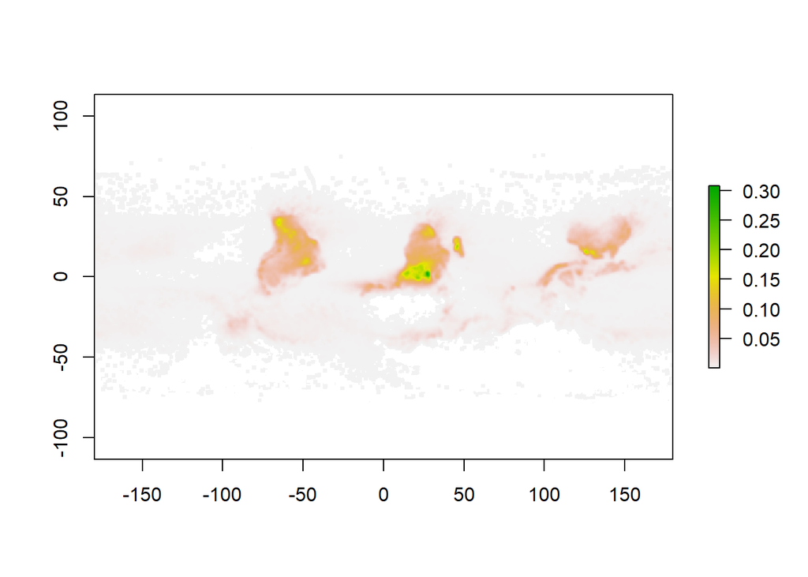

```r
## now is time to get a raster out of this

night <- raster(t(light.slice), xmn=min(lon), xmx=max(lon), ymn=min(lat), ymx=max(lat), crs=CRS("+proj=longlat +ellps=WGS84 +datum=WGS84 +no_defs+ towgs84=0,0,0"))



## now we plot it to see if the coordinates are oriented correctly

plot(night)  ### ok it seems flipped so we do
```

```r
night <- flip(night, direction='y') ##to be sure if you need to flip x or y direction just try and you will see

night<- projectRaster(night, crs = "+proj=longlat +ellps=WGS84 +datum=WGS84 +no_defs +towgs84=0,0,0")



#writeRaster(night, here("data","tmp","night_light_world.tiff"))
#### POPULATION DATA

## open population data from SEDAC that is stored as a GeoTiff

pop <- raster(here("data","raw","raster","sedac_pop_2000.TIFF"))


## check the crs

crs(night)
```

```
## Coordinate Reference System:
## Deprecated Proj.4 representation: +proj=longlat +datum=WGS84 +no_defs
## WKT2 2019 representation:
## GEOGCRS["unknown",
##     DATUM["World Geodetic System 1984",
##         ELLIPSOID["WGS 84",6378137,298.257223563,
##             LENGTHUNIT["metre",1]],
##         ID["EPSG",6326]],
##     PRIMEM["Greenwich",0,
##         ANGLEUNIT["degree",0.0174532925199433],
##         ID["EPSG",8901]],
##     CS[ellipsoidal,2],
##         AXIS["longitude",east,
##             ORDER[1],
##             ANGLEUNIT["degree",0.0174532925199433,
##                 ID["EPSG",9122]]],
##         AXIS["latitude",north,
##             ORDER[2],
##             ANGLEUNIT["degree",0.0174532925199433,
##                 ID["EPSG",9122]]]]
```

```r
crs(pop)
```

```
## Coordinate Reference System:
## Deprecated Proj.4 representation: +proj=longlat +datum=WGS84 +no_defs
## WKT2 2019 representation:
## GEOGCRS["unknown",
##     DATUM["World Geodetic System 1984",
##         ELLIPSOID["WGS 84",6378137,298.257223563,
##             LENGTHUNIT["metre",1]],
##         ID["EPSG",6326]],
##     PRIMEM["Greenwich",0,
##         ANGLEUNIT["degree",0.0174532925199433],
##         ID["EPSG",8901]],
##     CS[ellipsoidal,2],
##         AXIS["longitude",east,
##             ORDER[1],
##             ANGLEUNIT["degree",0.0174532925199433,
##                 ID["EPSG",9122]]],
##         AXIS["latitude",north,
##             ORDER[2],
##             ANGLEUNIT["degree",0.0174532925199433,
##                 ID["EPSG",9122]]]]
```

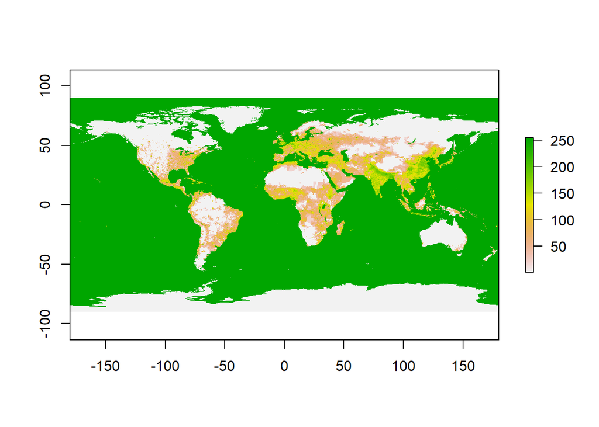

```r
## sanity check plots


plot(pop)
```

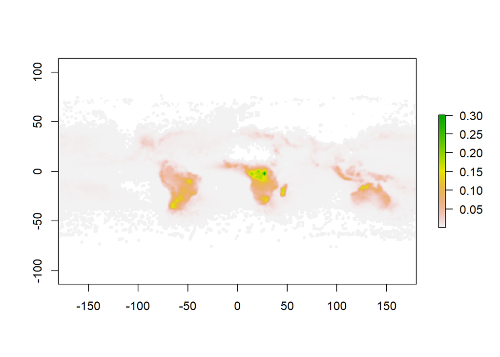

```r
plot(night)
```

```r
## we open also the word borders as a vector to have some maps of reference for plots

world_map <- ne_countries(scale = "medium", returnclass = "sf")
```

# MANIPULATING RASTER DATA

## Cropping rasters

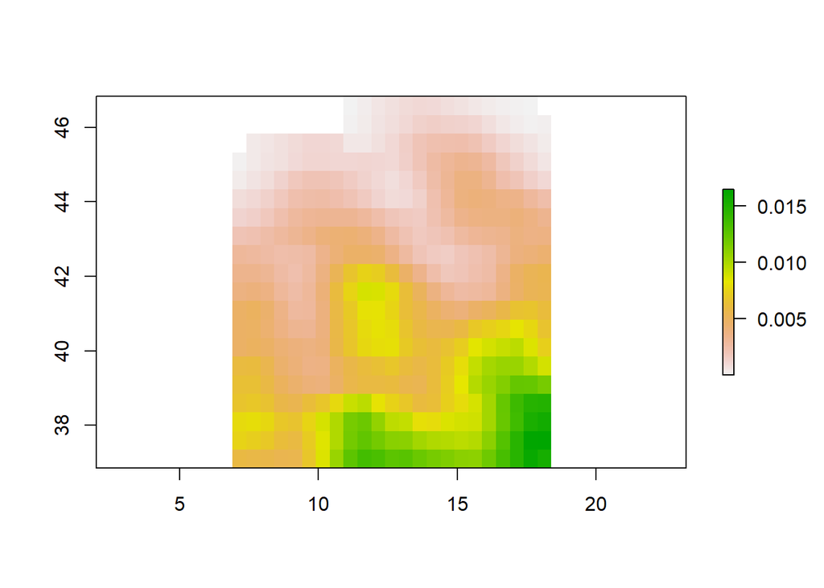

```r
## First we take the word_map and keep only the shape of Germany

ita_map <- world_map |>
  filter(sovereignt == "Italy")

## now we create a box around the germany map

ita_box <- st_bbox(ita_map)


## now we can use the crop function

ita_light <- crop(night,ita_map)
ita_pop <- crop(pop,ita_map)

# it would work also if the raster object was a spatial raster from terra instead, or if instead of a bbox object we had a normal sf object on the second argument.


## let´s plot vector and raster to see if the images make sense

plot(ita_light)
```

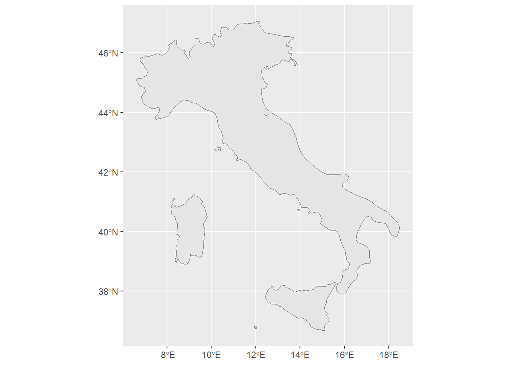

```r
ggplot()+
  geom_sf(data = ita_map)
```

## Masking rasters

Instead of cropping we can mask the raster. The difference is that the cropping is effectively deleting all the information not contained within the geometry extent of the second argument while masking will keep all the information but set to 0 the values for outside the extent indicated by the reference object.

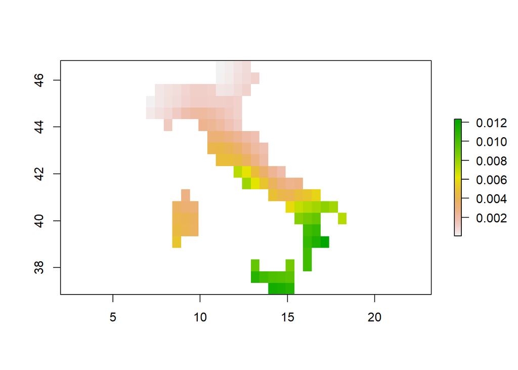

```r
## To use mask the second object should be an sf object so we cannot use directly the bbox we should convert it to a an sf object or we can use directly the ita_map

ita_mask <- mask(ita_light, ita_map)
ita_pop_mask <- mask(ita_pop, ita_map)
plot(ita_mask)
```

Comparing masking and cropping operations you can see that the masking is producing a more clear picture because you can see exactly which grid cells /tiles are within the geometry

But it could be less convenient if you start from the world map:

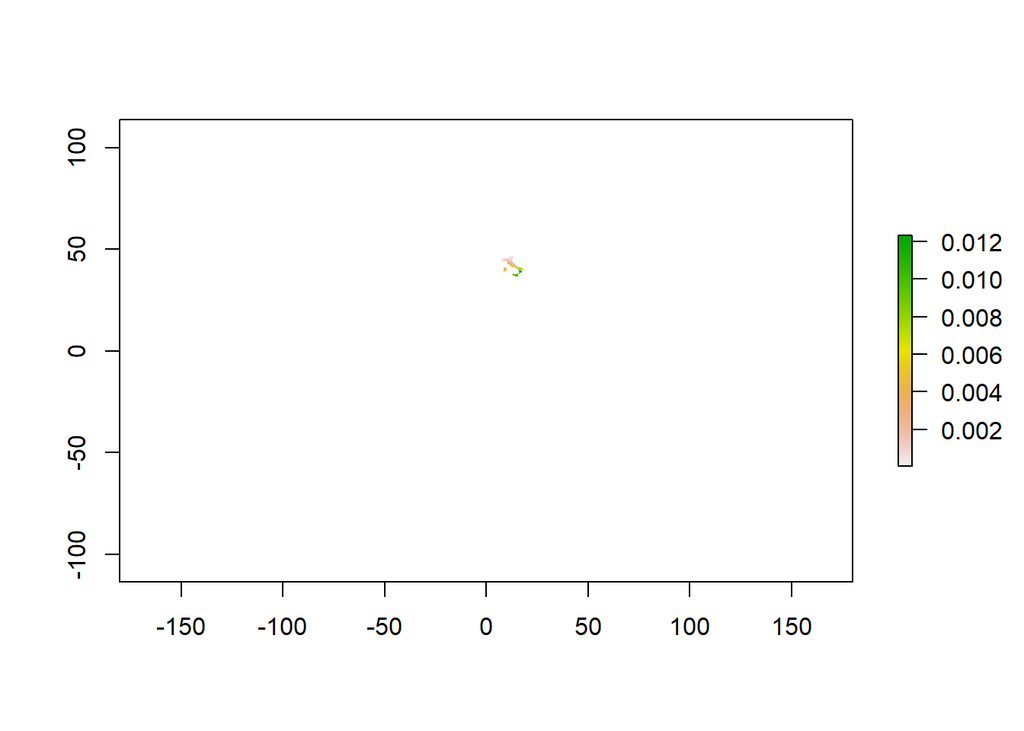

```r
ita_tot_mask <- mask(night, ita_map)

plot(ita_tot_mask)
```

As you see above italy is small and the rest of the world is not erased but just set to 0. So ideally you first crop on a bbox and then you mask to get a more clean picture.

## Resampling rasters

```r
res(ita_mask)
```

```
## [1] 0.499 0.499
```

```r
res(ita_pop_mask)
```

```
## [1] 0.1 0.1
```

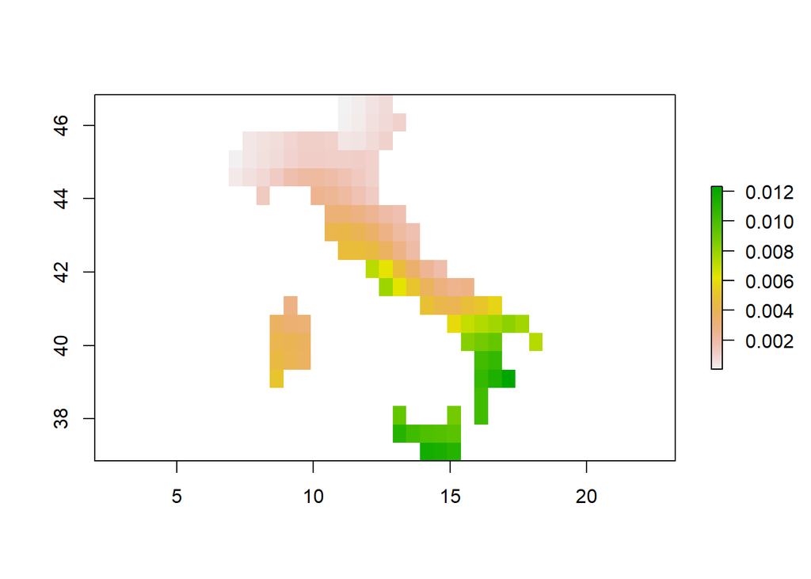

```r
plot(ita_mask)
```

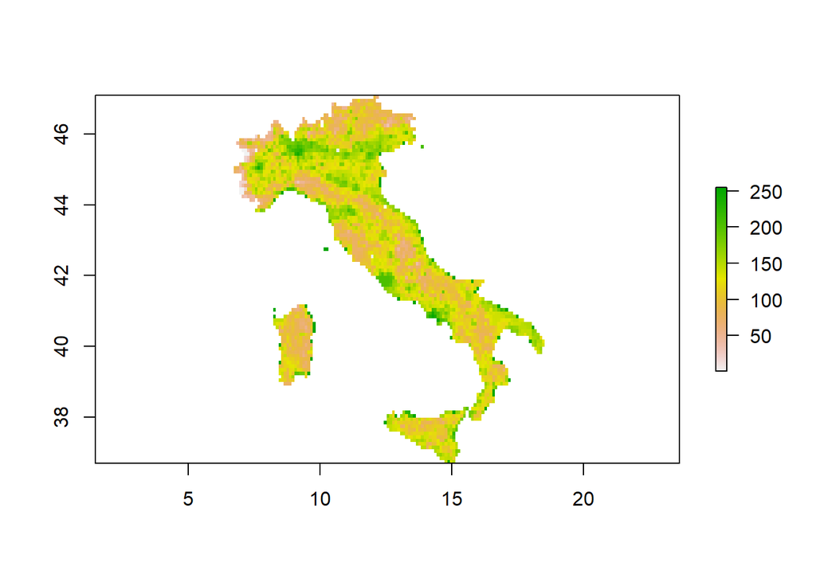

```r
plot(ita_pop_mask)
```

As you can see the first raster is bigger than the second and this can be seen by the resolution number (0.5 versus 0.1) but also visually from the maps.

Ideally we always want more precise information so smaller grid, but this is not always possible and it is very likely that you will need to work in the same project with rasters with different resolutions.

To deal with this you can resample the raster to homogenize the resolution. You can go from the smaller to the bigger safely but you will loose data quality if you go from a bigger raster to a smaller resample.

```r
## We start by making the population data have cells as big as the one of the night lights

resampled_ita_pop <- resample(ita_pop_mask, ita_mask, method="bilinear")

## now we check for the resolution

res(resampled_ita_pop)
```

```
## [1] 0.499 0.499
```

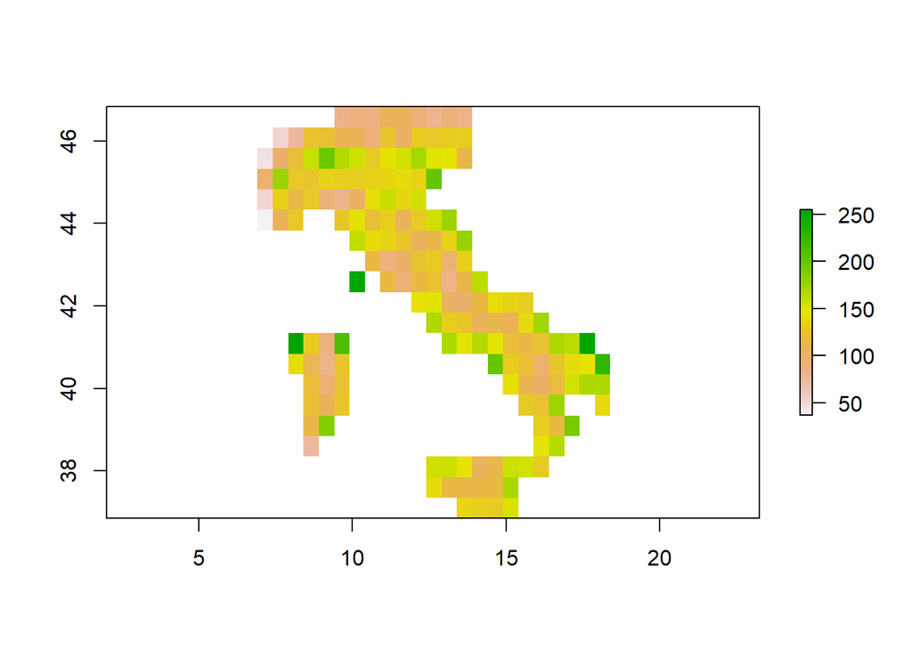

```r
plot(resampled_ita_pop)
```

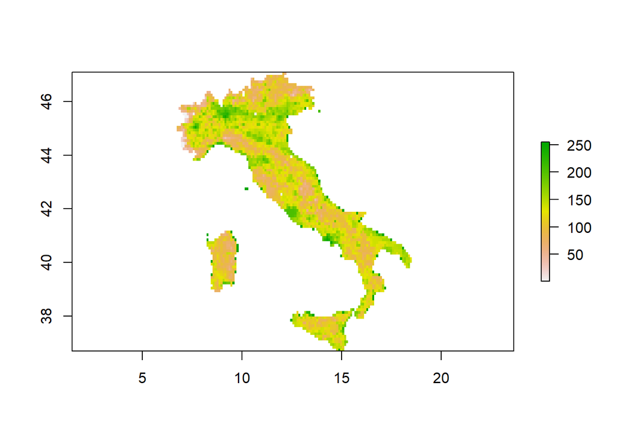

```r
plot(ita_pop_mask)
```

## Aggregating and Disaggregating rasters

Another strategy that can be used to reduce the number of cells or get a value for an entire area is to aggregate the raster into bigger units.

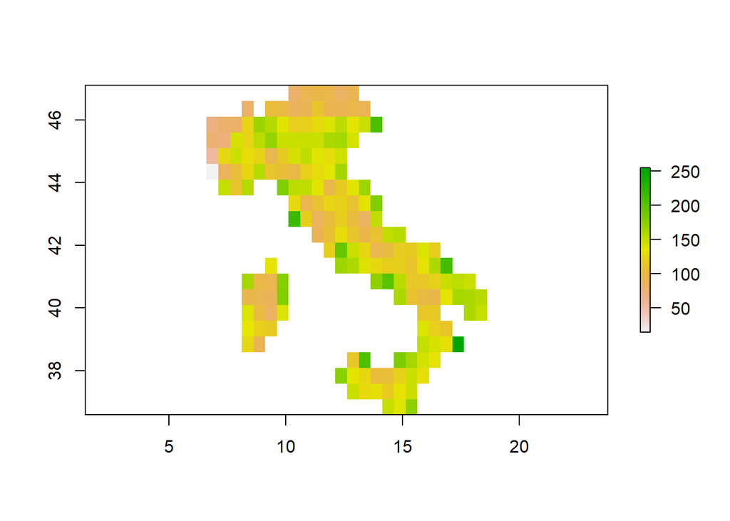

```r
agg_ita_pop <- aggregate(ita_pop_mask, fact = 5, fun=mean, expand=TRUE, na.rm=TRUE)

## now i used a factor of 5 so from 0.1 x 5 we should get an image similar to the previous one resampling

plot(agg_ita_pop)
```

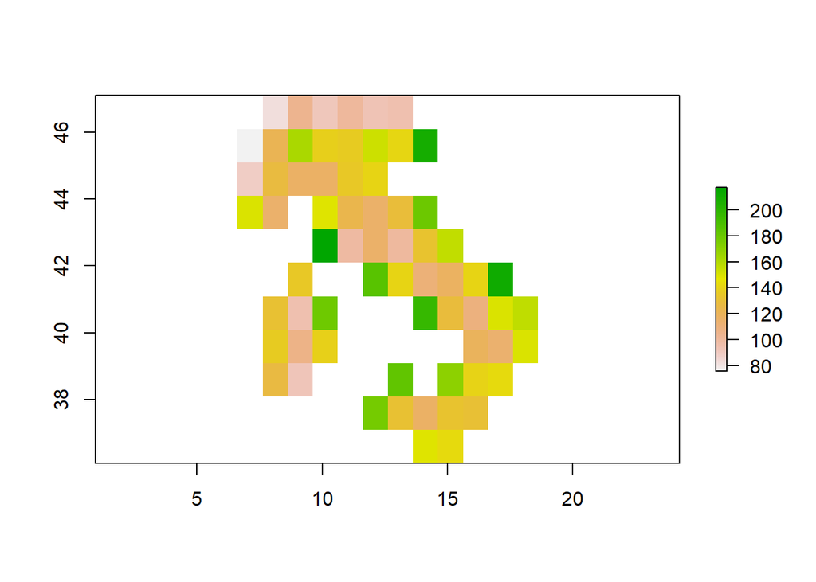

```r
# We can also use a bigger aggregation factor

reagg_ita_pop <- aggregate(ita_pop_mask, fact = 10, fun=mean, expand=TRUE, na.rm=TRUE)


plot(reagg_ita_pop)
```

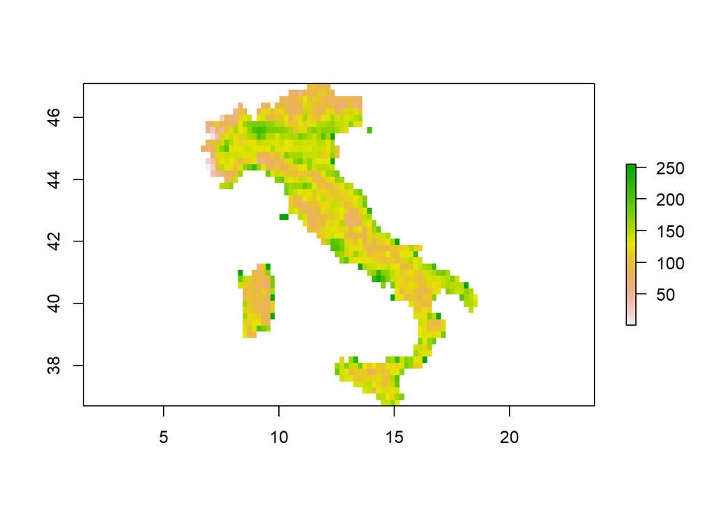

```r
# Or a smaller one


deagg_ita_pop <- aggregate(ita_pop_mask, fact = 2, fun=mean, expand=TRUE, na.rm=TRUE)


plot(deagg_ita_pop)
```

Now if we want to disaggregate, so go to smaller cells, we can do it with the disaggregate function and we need to specify again the factor and the method, so again we will use bilinear so that values are locally interpolated and we introduce the smallest amount possile of measurement error.

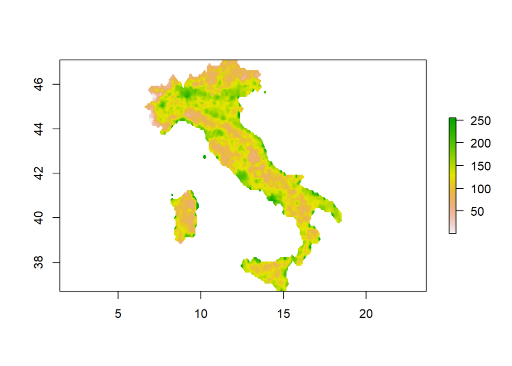

```r
smaller_pop <- disaggregate(ita_pop_mask, fact=2, method='bilinear')

plot(smaller_pop)
```

The smaller we get the nicer it looks in visualizations but also the less precise it is if we are starting from a larger raster, keep this trade-off in mind.

# RASTER to RASTER OPERATIONS

## Putting one raster on top of the other : overlaying

We can do this with the ** overlay ** function from the raster package.

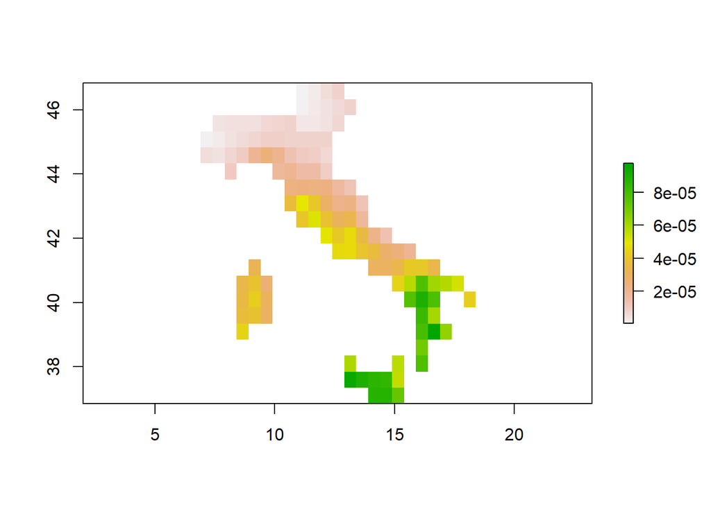

```r
pop_night <- overlay(ita_mask, resampled_ita_pop, fun=function(x,y) x/y)

plot(pop_night)
```

Another way to handle operations across raster layers is to use more advanced types of rasters objects called : raster brick and raster stacks that we will cover in the 5th class in some weeks, they allow you to work with multiple layers all at the same time in one object and do operations across them.

# RASTER to VECTOR OPERATIONS

## Extracting values from rasters

Many times what we really want is to know from these satellite images how much is the total or mean value across pixels for one specific geographic unit.

### We can extract the values from a raster to the extent of another spatial object using extract or exact_extract functions and package

```r
##open shape file
ita_2 <- st_read(here("data","raw", "gadm41_ITA_shp", "gadm41_ITA_2.shp"))
##crop and then mask the raster of night light as we learnt above

ita_night <- crop(night, ita_2)
ita_mask <- mask(ita_night, ita_2)  ## this might take a while

## Now we can extract

values <- exact_extract(ita_mask, ita_2, 'sum')
```

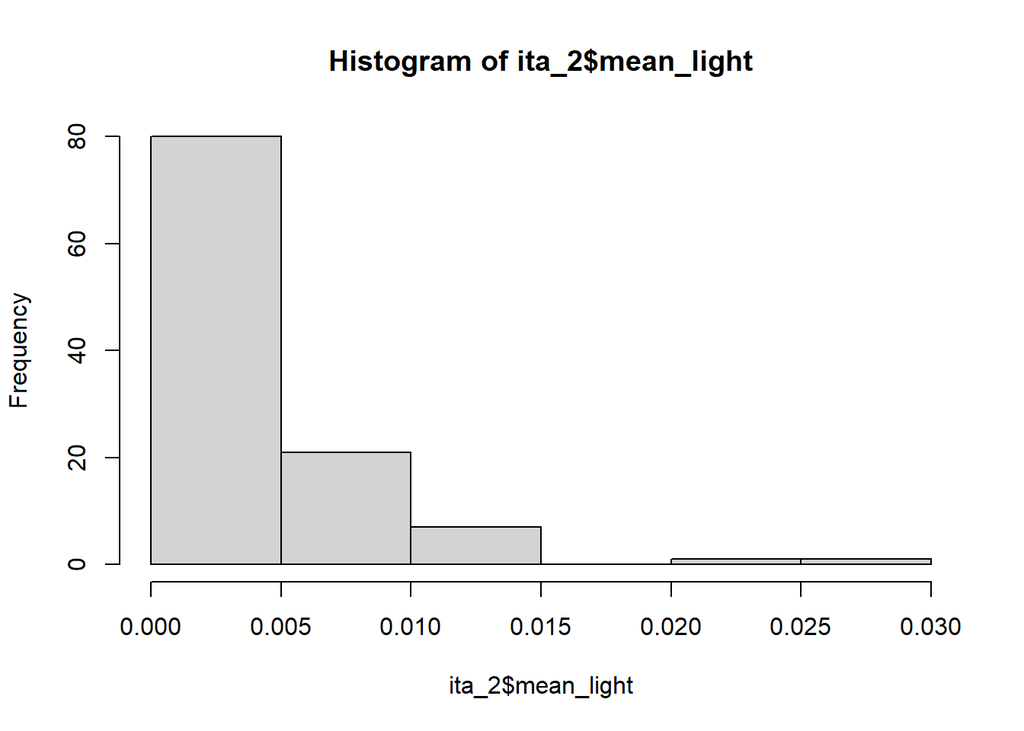

```r
## the function is returning a vector and we can assign it to a column in our shapefile so that later is easier to plot and in general you can do this with the dataset you will use for e.g. for regressions

ita_2$mean_light <- values

## let´s look at the distribution of the lights first
hist(ita_2$mean_light)  ## looks legit we can plot it
```

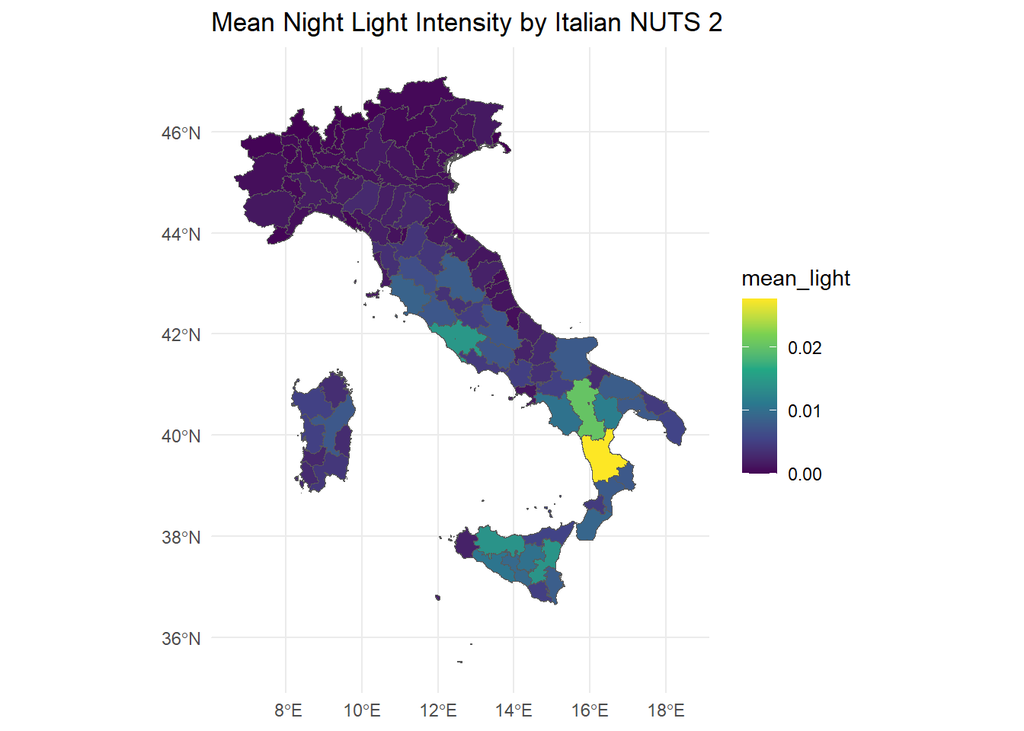

```r
ita_night_plot <- ggplot() +
  geom_sf(data = ita_2, aes(fill = mean_light)) +
  scale_fill_viridis_c() +
  theme_minimal() +
  labs(title = "Mean Night Light Intensity by Italian NUTS 2")

print(ita_night_plot)
```

There are many more advance feature of the exact_extract function, for eg. is possible to compute multiple statistics at the same time and store then automatically in a dataframe or to weight the statistic for the precise share of raster cells covered by the polygons (to adjust for the bias coming from cells that are half in and half out of the geometry).

There is also a default raster::extract where you can do similar operations but it is more commonly used for raster to raster operations.

# For when you want switch from rasters to vectors and viceversa

## From vector to raster : rasterization

There are ways to go from vectors to raster and viceversa. They can be quite time consuming and are most of the time not the best choice. Although they can be really necessary in some situations.

All the parts of the sfc features can be potentially rasterized, there can be line rasterization, point rasterization and full polygons rasterization.

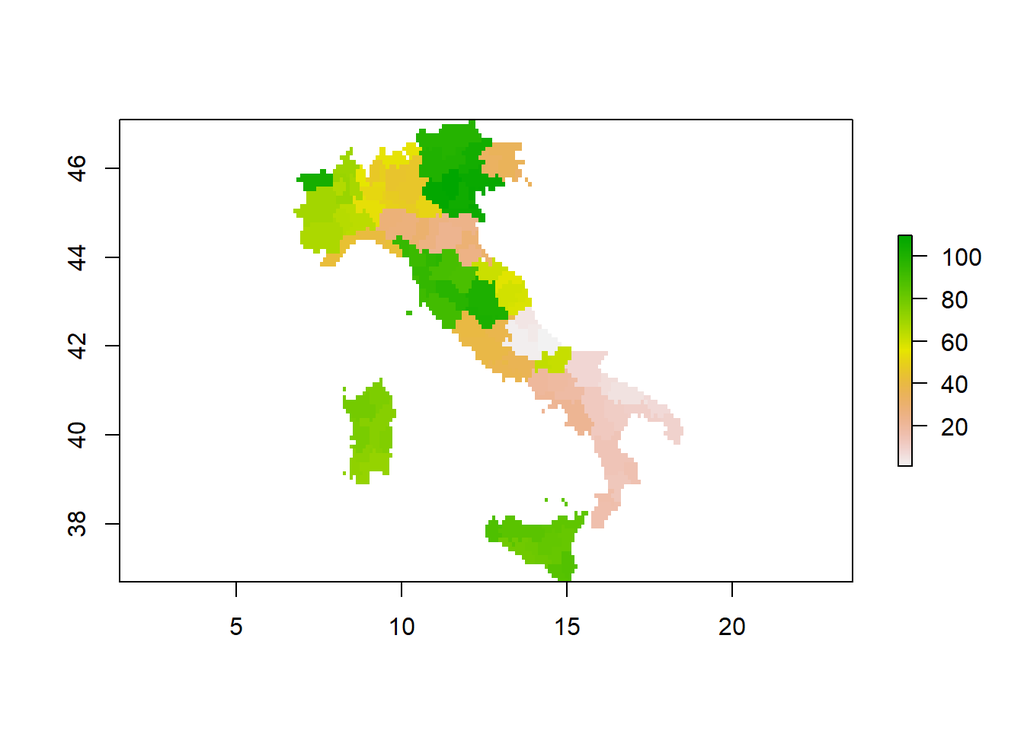

```r
## We start from the ita_2 data and we make them a  raster using as a template the masked population raster

rast_ita_2 <- rasterize(ita_2, ita_pop_mask)

plot(rast_ita_2)
```

```r
str(rast_ita_2)
```

[output not shown]

[output cut: 16 more lines]

[output not shown]

## From raster to vector : spatial vectorization

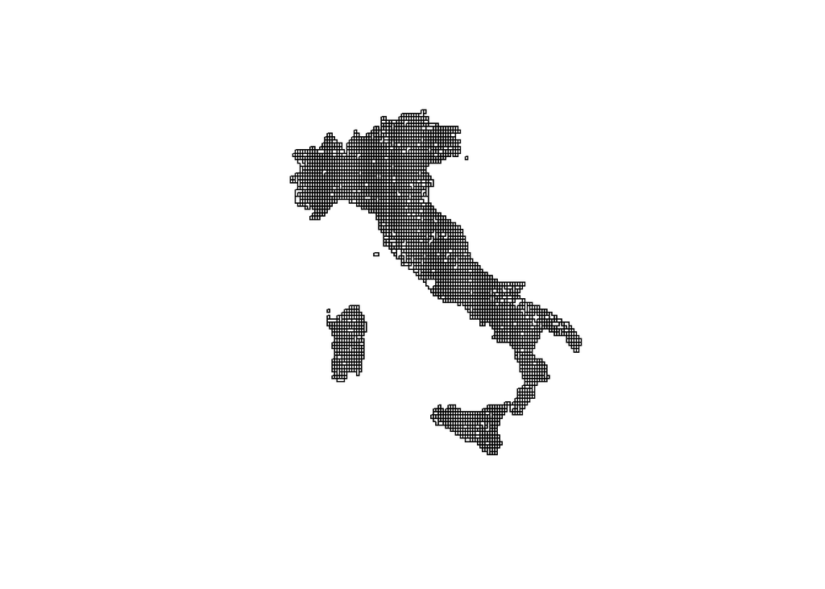

```r
# Here we start from the ita_pop_mask and we make it a polygon

diss_poly_pop <- rasterToPolygons(ita_pop_mask, dissolve = TRUE)
poly_pop <- rasterToPolygons(ita_pop_mask, dissolve = FALSE)

plot(diss_poly_pop)
```

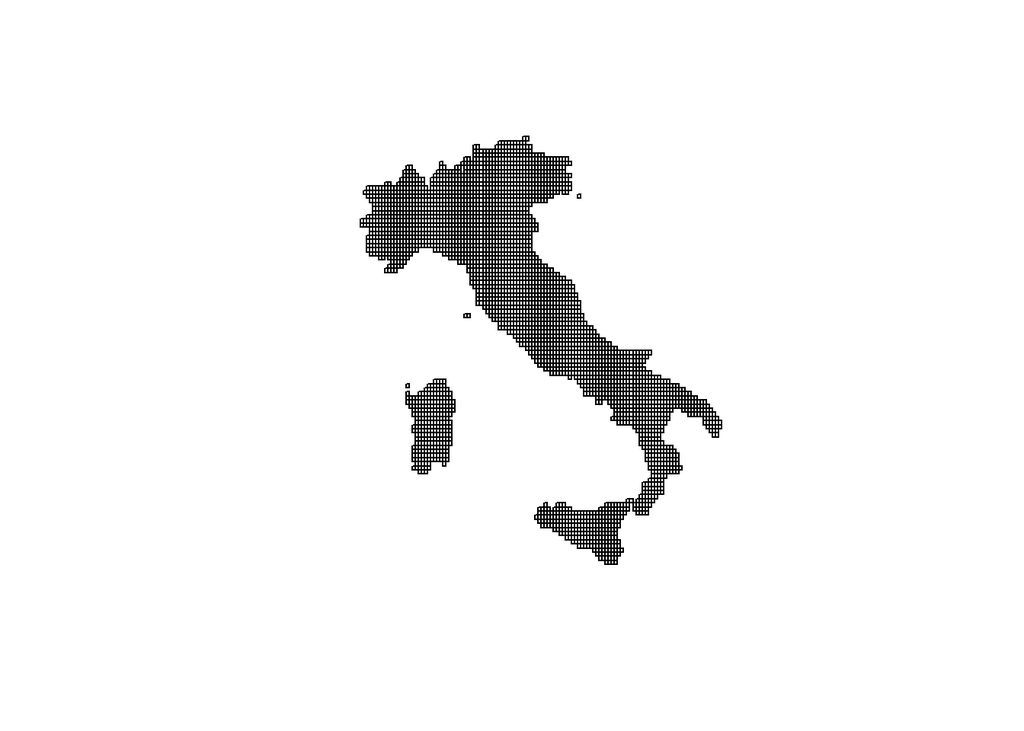

```r
plot(poly_pop)
```

# SPATIAL OPERATIONS TO GET RASTER INSIGHTS

- st_buffer()
- st_centroid()
- st_distance()
- st_area()

Now that we can use rasters and vectors at the same time many interesting things are possible.

We will try to get insights on the population distribution around province centers using our 0.1 x 0.1 degrees raster cells data each containing information on ~ 11.1 km.

```r
ita_3 <- st_read(here("data","raw", "gadm41_ITA_shp", "gadm41_ITA_3.shp"))
## now we select sicily

sicily <- ita_3 |>
  filter(NAME_1 == "Sicily")

## let´s zoom in little and do it with one province


 messina <- ita_3 |>
  filter(NAME_2 == "Messina")


 messina_centers <- st_centroid(messina)
```

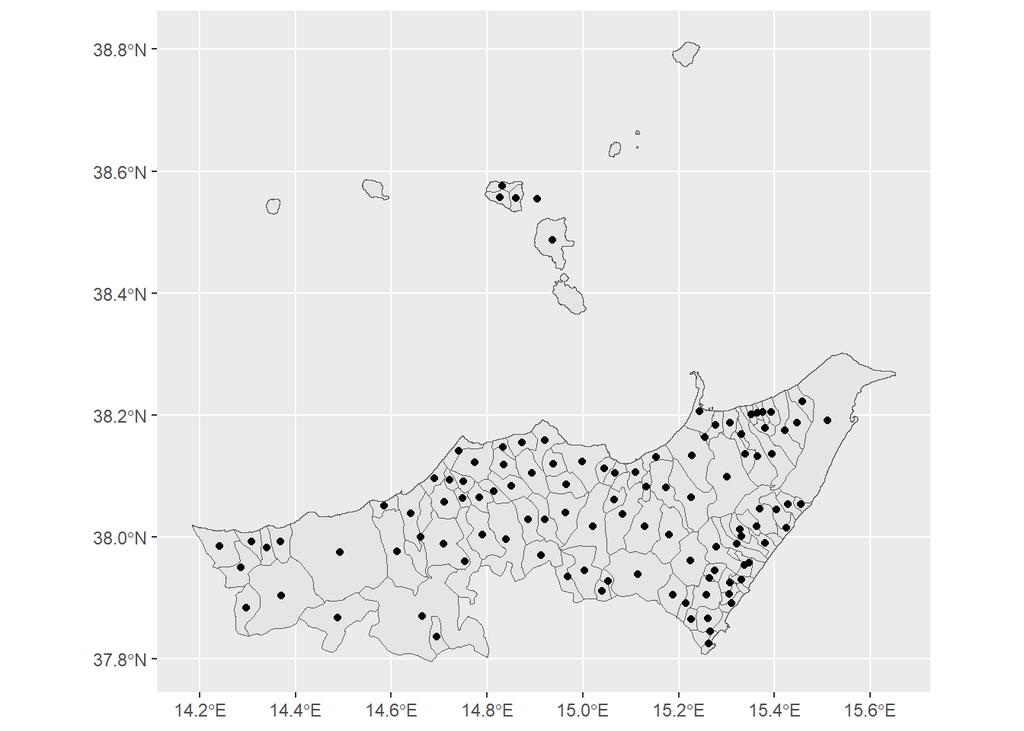

```r
 ggplot()+
  geom_sf(data=messina) +
  geom_sf(data=messina_centers)
```

```r
 #It is visible how some of the centers are not really inside of the polygons, especially for islands, we can correct for that using st_point_on_surface()  function instead of st_centroids


re_messina_centers <- st_point_on_surface(messina)
```

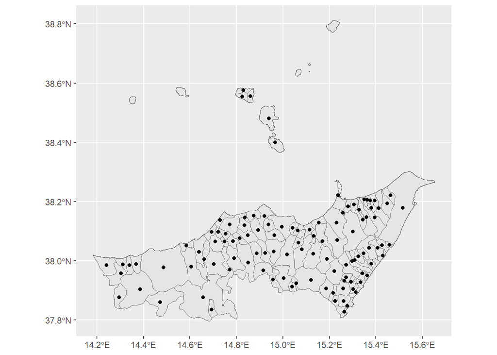

```r
 ggplot()+
  geom_sf(data=messina) +
  geom_sf(data=re_messina_centers)
```

```r
 ## now we can generalize for all Italy

ita_centers <- st_point_on_surface(ita_3)
```

STEP 2: Create a buffer around the centroids of 2 kilometers and extract values from the ita_pop_mask raster dataset for geometries of centroids + buffers

```r
# define 2km buffer distance
buffer_distance <- 2000

# use st_buffer function from the sf package to create buffer around centroids
centers_buffer <- st_buffer(ita_centers, dist = buffer_distance)

# Extract values from hte centers raster dataset for centroids + buffers

pop_centers <- exact_extract(ita_pop_mask, centers_buffer, fun = "sum")
# Extract values for all NUTS 3 using the initial shapefile as extent

pop_tot <- exact_extract(ita_pop_mask, ita_3,  fun = "sum")
```

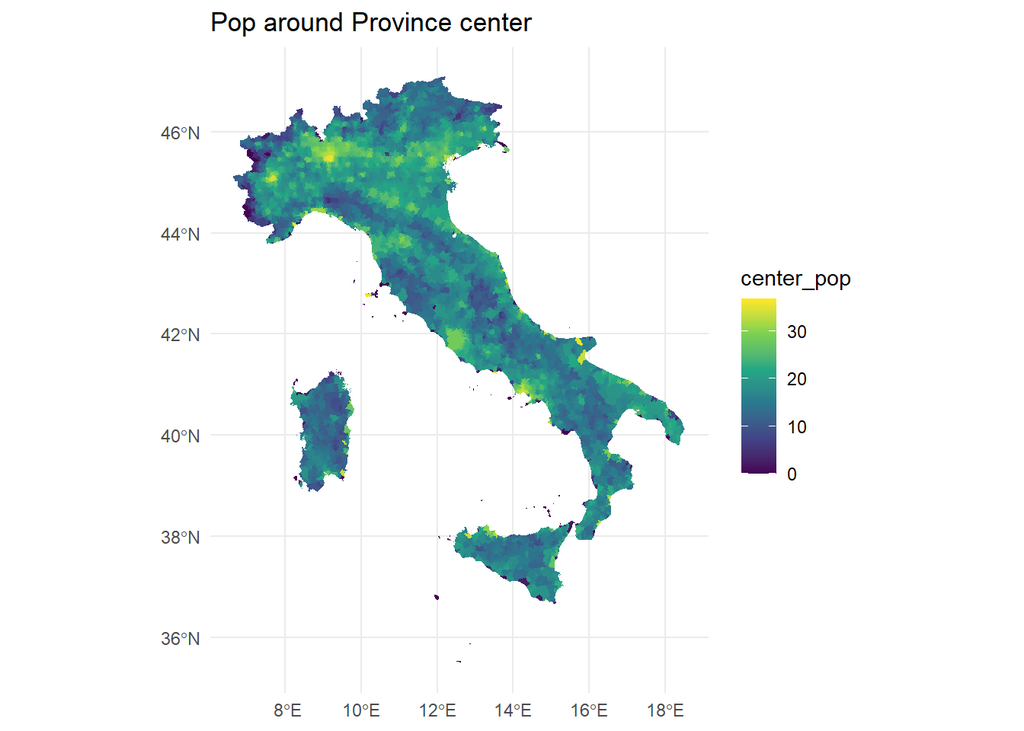

```r
# Assign the extracted values

ita_3$non_center_pop  <- pop_tot - pop_centers

ita_3$center_pop <- pop_centers


#plot


ggplot() +
  geom_sf(data = ita_3, aes(fill = center_pop), color= NA) +
  labs(title = "Pop around Province center") +
  theme_minimal()+
  scale_fill_viridis_c()
```

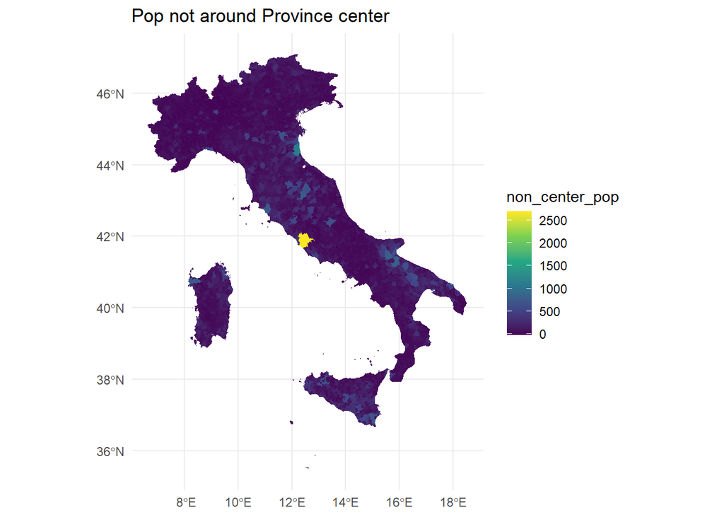

```r
ggplot() +
  geom_sf(data = ita_3, aes(fill = non_center_pop), color= NA) +
  labs(title = "Pop not around Province center") +
  theme_minimal()+
  scale_fill_viridis_c()
```